# Introduction to lifelogr

2017-03-20

```r
library(lifelogr) # doesn't work yet
```

[Lifelogging][http://lifestreamblog.com/lifelogging/] is the “process of tracking personal data generated by our own behavioral activities.” Examples of lifelogging include tracking one’s exercise and sleep. While devices like iPhones and fitbits make collecting data on oneself easy, interpreting that data is more difficult.

The lifelogr package makes life logging easy by:

- Creating three sets of visualizations
- Creating an experimentation framework

This package was designed to work with fitbit data, but users can also provide their own data. However, except for Apple data, the data types must match that provided here for lifelogr’s functions to work.

## Data

Fitbit users can provide their username and password. Fitbit allows login via Facebook and Google, but this library only works with fitbit login.

```r
EX <- Person$new(fitbit_user_email = "example@domain.com",
                 fitbit_user_pw = "password",
                 apple_data_file = "apple.csv",
                 addl_data = NA,
                 user_info = list("name" = "EX", "age" = 29, "gender" = "male"),
                 target_steps = 10000,
                 group_assignments = list(data.frame(NA), data.frame(NA)),
                 start_date = "2017-01-19", end_date = "2017-02-17")
```

```r
load("../data/EX.rda")
# data(EX)
```

iPhone users can provide their Apple data as a csv. There is an iOS app called QS Access (quantified self) where you can select which measures you would like and on which time scale (by day or by hour), and it will create a csv file for you. For greater compatibility with the lifelogr package, users are highly recommended to select the “by hour” time interval.

Users can provide other sources of data as a data frame, as an argument to `addl_data` or `addl_data2`.

EX is an instance of the Person class, which has 3 main public data frames: `fitbit_daily`, `fitbit_intraday`, and `util`.

Here is the structure of `fitbit_daily`, which has fitbit data recorded on a daily basis.

```r
dplyr::glimpse(EX$fitbit_daily)
```

```
#> Observations: 30
#> Variables: 33
#> $ steps                              <dbl> 7749, 8468, 17615, 2421, 15...
#> $ distance                           <dbl> 3.0623968, 3.3727345, 6.961...
#> $ floors                             <dbl> 43, 56, 29, 19, 67, 29, 65,...
#> $ minutesVery                        <dbl> 9, 3, 24, 0, 20, 10, 2, 0, ...
#> $ caloriesBurned                     <dbl> 1767, 1763, 2079, 1407, 226...
#> $ caloriesIntake                     <dbl> 0, 0, 0, 0, 0, 0, 0, 0, 0, ...
#> $ restingHeartRate                   <dbl> 59.44165, 59.47979, 59.5278...
#> $ date                               <date> 2017-01-19, 2017-01-20, 20...
#> $ dateInForJavascriptLocalFormatting <chr> "January 19, 2017", "Januar...
#> $ startTime                          <chr> "23:28", "23:47", "23:46", ...
#> $ endTime                            <chr> "8:12", "6:56", "10:15", "7...
#> $ sleepDuration                      <int> 524, 429, 629, 448, 462, 47...
#> $ startDateTime                      <chr> "2017-1-18 23:28:30", "2017...
```

[output cut: 20 more lines]

Here is the structure of `fitbit_intraday`, which has fitbit data recorded on an intraday basis, generally every 15 minutes, although for certain variables, such as heart rate, every 5 minutes.

```r
dplyr::glimpse(EX$fitbit_intraday)
```

```
#> Observations: 8,631
#> Variables: 17
#> $ time            <dttm> 1970-01-01 09:09:29, 1970-01-01 00:00:00, 197...
#> $ steps           <dbl> NA, 0, NA, NA, 0, NA, NA, 0, NA, NA, 0, NA, NA...
#> $ distance        <dbl> NA, 0, NA, NA, 0, NA, NA, 0, NA, NA, 0, NA, NA...
#> $ floors          <dbl> NA, 0, NA, NA, 0, NA, NA, 0, NA, NA, 0, NA, NA...
#> $ activeMin       <dbl> NA, 0, NA, NA, 0, NA, NA, 0, NA, NA, 0, NA, NA...
#> $ calories-burned <dbl> NA, 11.95200, NA, NA, 11.95200, NA, NA, 11.952...
#> $ activityLevel   <chr> NA, "SEDENTARY", NA, NA, "SEDENTARY", NA, NA, ...
#> $ bpm             <int> NA, 57, 59, 60, 60, 61, 60, 61, 62, 63, 65, 64...
#> $ confidence      <int> NA, 3, 3, 3, 3, 3, 2, 3, 3, 3, 2, 1, 2, 2, 1, ...
#> $ caloriesBurned  <dbl> NA, 3.98400, 3.98400, 3.98400, 3.98400, 3.9840...
#> $ defaultZone     <chr> NA, NA, NA, NA, NA, NA, NA, NA, NA, NA, NA, NA...
#> $ customZone      <lgl> NA, NA, NA, NA, NA, NA, NA, NA, NA, NA, NA, NA...
#> $ weight          <dbl> 101.3, NA, NA, NA, NA, NA, NA, NA, NA, NA, NA,...
#> $ datetime        <dttm> 2017-01-06 09:09:29, 2017-01-19 00:00:00, 201...
#> $ date            <date> 2017-01-06, 2017-01-19, 2017-01-19, 2017-01-1...
#> $ distanceKm      <dbl> NA, 0, NA, NA, 0, NA, NA, 0, NA, NA, 0, NA, NA...
#> $ weightKg        <dbl> 45.94887, NA, NA, NA, NA, NA, NA, NA, NA, NA, ...
```

Here is the structure of `fitbit_util`, which has information about the dates in the range specified by the user when creating the Person instantiation, such as day of week and month.

```r
dplyr::glimpse(EX$util)
```

```
#> Observations: 30
#> Variables: 5
#> $ date        <date> 2017-01-19, 2017-01-20, 2017-01-21, 2017-01-22, 2...
#> $ datetime    <dttm> 2017-01-18 16:00:00, 2017-01-19 16:00:00, 2017-01...
#> $ day_of_week <ord> Thurs, Fri, Sat, Sun, Mon, Tues, Wed, Thurs, Fri, ...
#> $ day_type    <fctr> weekday, weekday, weekend, weekend, weekday, week...
#> $ month       <ord> Jan, Jan, Jan, Jan, Jan, Jan, Jan, Jan, Jan, Jan, ...
```

Dates and times come in numerous forms. lifelogr uses three primary types of dates/times:

- date: “2017-03-20”
- time: “08:00:00”
- date-time: this refers to a combination of a date and a time and is the most common unit of analysis in this package

## Visualization

There are 3 functions which allow for a series of plots with just one function call: `plot_sleep_all`, `plot_daily_all`, and `plot_intraday_all`. Each acts like the `plot.lm` function, where users must click “enter” to see the next plot.

Each plot within the generic plot function can also be called individually.

Here are the sleep plots for EX:

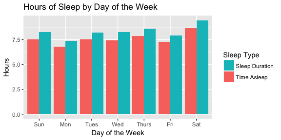

```
#> Press [enter] to continue
```

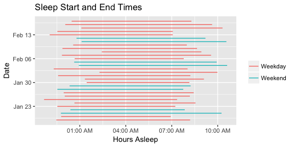

```
#> Press [enter] to continue
```

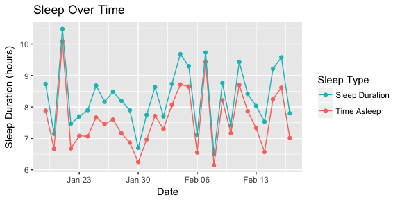

```
#> Press [enter] to continue
```

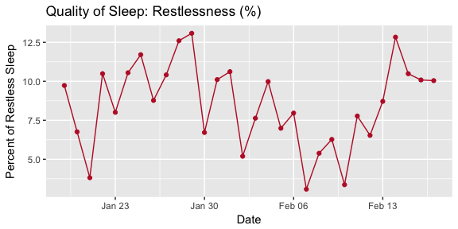

```
#> Press [enter] to continue
```

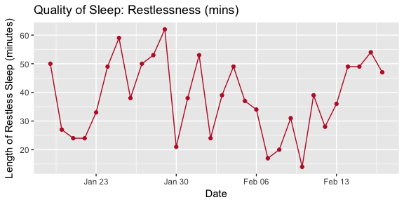

```
#> Press [enter] to continue
```

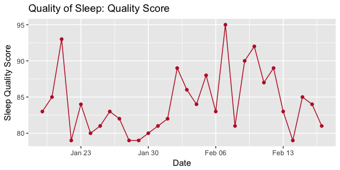

```
#> Press [enter] to continue
```

```r
plot_sleep_all(EX)
```

Users can also call each function individually using `plot_sleep(person, plot_type)`. For example:

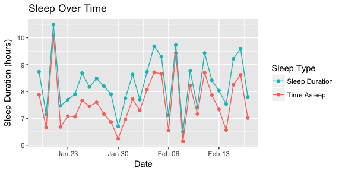

```r
plot_sleep(EX, "by_datetime")
```

Some plots have other options.

For example, `plot_sleep_start_end` has a `color_var = "day_of_week"` argument to color the lines by day of the week instead of weekend/weekday.

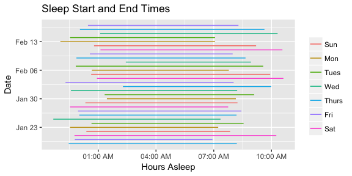

```r
plot_sleep_start_end(EX, "day_of_week")
```

Here are the plots for the daily totals for EX:

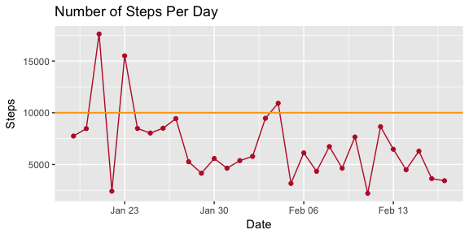

```
#> Press [enter] to continue
```

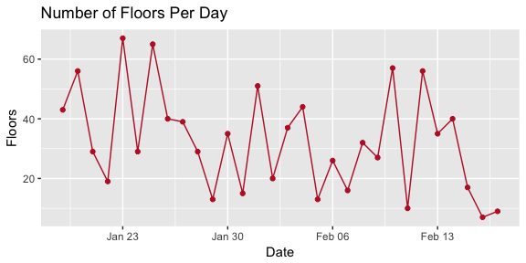

```
#> Press [enter] to continue
```

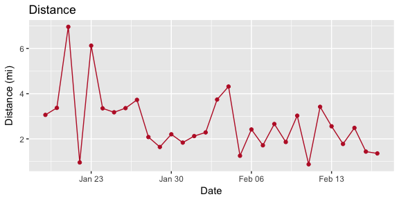

```
#> Press [enter] to continue
```

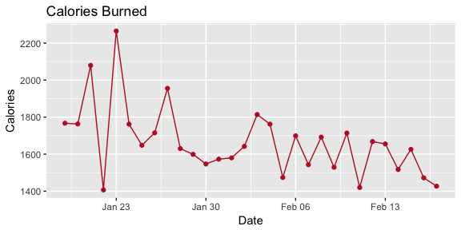

```
#> Press [enter] to continue
```

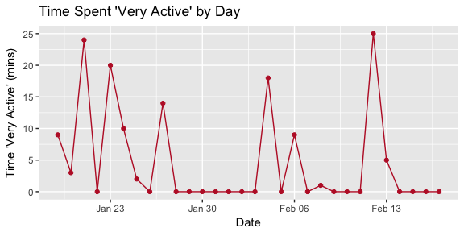

```
#> Press [enter] to continue
```

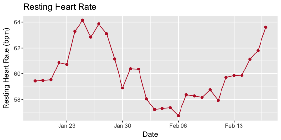

```
#> Press [enter] to continue
```

```r
plot_daily_all(EX)
```

Users can also call each function individually using:

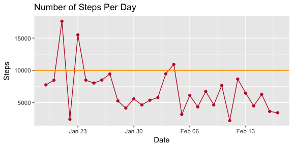

```r
plot_daily(EX, "steps")
```

Here are the plots for intraday data (multiple data points collected within each day). The default is to aggregate the data by time intervals within each day so that data for a “typical day” is displayed.

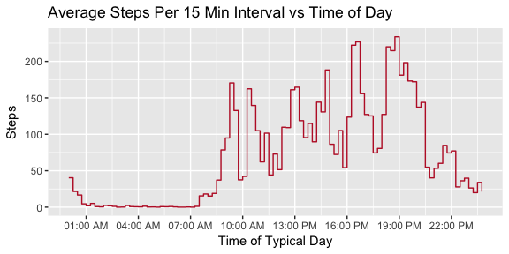

```
#> Press [enter] to continue
```

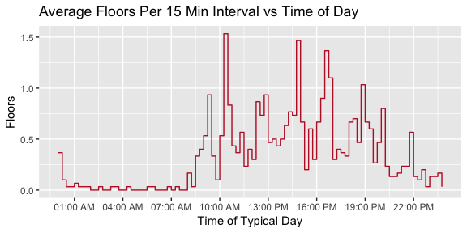

```
#> Press [enter] to continue
```

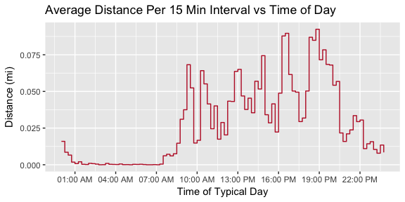

```
#> Press [enter] to continue
```

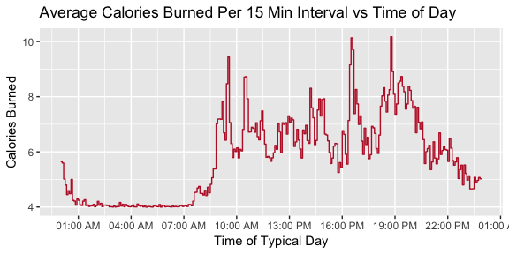

```
#> Press [enter] to continue
```

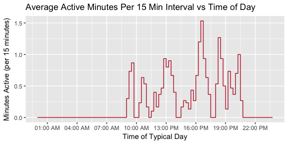

```
#> Press [enter] to continue
```

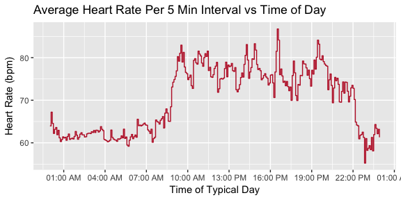

```
#> Press [enter] to continue
```

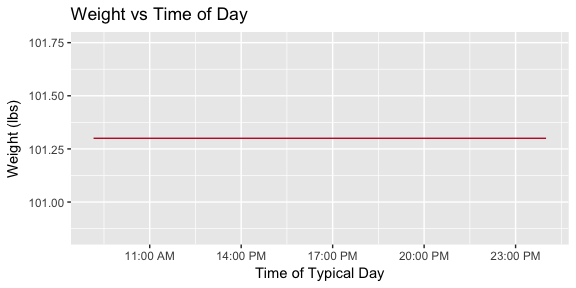

```
#> Press [enter] to continue
```

```r
plot_intraday_all(EX)
```

However, it is also possible to specify that the plots use the raw data and plot over all date-times.

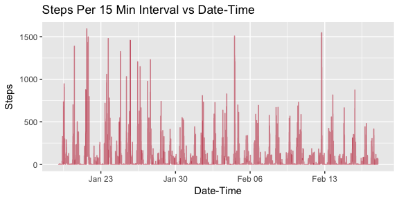

```
#> Press [enter] to continue
```

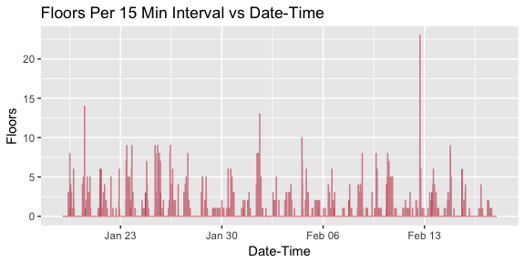

```
#> Press [enter] to continue
```

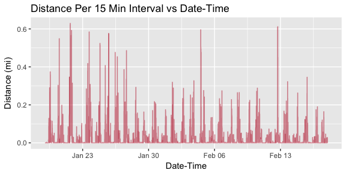

```
#> Press [enter] to continue
```

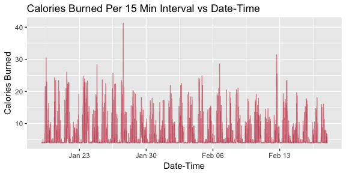

```
#> Press [enter] to continue
```

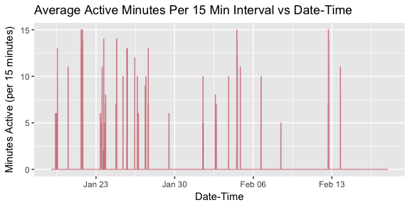

```
#> Press [enter] to continue
```

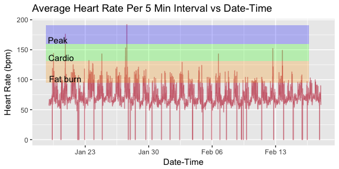

```
#> Press [enter] to continue
```

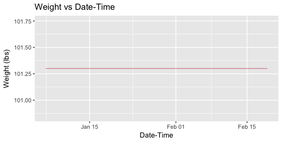

```
#> Press [enter] to continue
```

```r
plot_intraday_all(EX, FALSE)
```

## Experimentation Framework

While almost all the visualizations shown above had date, date-time, or time on the x axis, the experimentation framework allows for greater flexibility. Users can select any variables of interest and examine their relationship.

The `experiment` function will study every pairwise combination of the variable and measure variables given.

1. Plots To plot the relationship between sleep duration and resting heart rate and the relationship between day of week and resting heart rate:

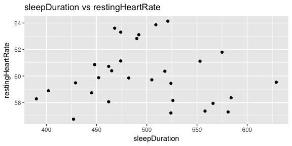

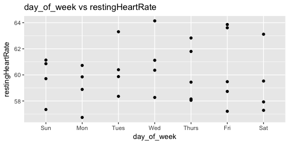

   ```r
   experiment(person = EX, variables = list("fitbit_daily" = c("sleepDuration"),
                                            "util" = c("day_of_week")),
              measures = list("fitbit_daily" = c("restingHeartRate")),
              analysis = c("plot"),
              time_var = c("date"))
   ```

```r
# Looks similar - don't need both
# dataset <- create_dataset(person = EX,
#                           all_variables = list("util" = c("month"),
#                                                "fitbit_daily" = c("steps")),
#                           time_var = c("date"))
#
# l_plot(dataset, person = EX, variables = list("util" = c("month")),
#        measures = list("fitbit_daily" = c("steps")))
```

```r
dataset <- create_dataset(person = EX,
                          all_variables = list("fitbit_daily" = c("sleepDuration",
                                                                  "steps")),
                          time_var = c("date"))

correlation_df <- correlation(dataset, person = EX,
                              variables = list("fitbit_daily" = c("sleepDuration")),
                              measures = list("fitbit_daily" = c("steps")),
                              time_var = "date")
```

```
#>                   steps
#> sleepDuration 0.1863556
```

```r
dataset <- create_dataset(person = EX,
                          all_variables = list("util" = c("day_of_week"),
                                               "fitbit_daily" = c("sleepDuration",
                                                                  "steps",
                                                                  "restingHeartRate")),
                          time_var = c("date"))

all_anovas <- l_anova(dataset, person = EX, variables = list("util" = c("day_of_week"),
                                               "fitbit_daily" = c("sleepDuration",
                                                        "steps")),
       measures = list("fitbit_daily" = c("restingHeartRate")))
```

```
#> [1] "restingHeartRate ~ (day_of_week + sleepDuration + steps)^2"
#> Analysis of Variance Table
#>
#> Response: restingHeartRate
#>                           Df Sum Sq Mean Sq F value Pr(>F)
#> day_of_week                6 11.241  1.8735  0.3106 0.9142
#> sleepDuration              1  0.315  0.3152  0.0523 0.8249
#> steps                      1  1.322  1.3216  0.2191 0.6522
#> day_of_week:sleepDuration  6 41.841  6.9734  1.1562 0.4126
#> day_of_week:steps          6 31.007  5.1679  0.8568 0.5625
#> sleepDuration:steps        1  0.809  0.8089  0.1341 0.7237
#> Residuals                  8 48.250  6.0313
```

```r
all_models <- l_regression(dataset, person = EX, variables = list("util" = c("day_of_week"),
                                                             "fitbit_daily" = c("sleepDuration",
                                                                                "steps")),
                      measures = list("fitbit_daily" = c("restingHeartRate")))
```

```
#> [1] "restingHeartRate ~ (day_of_week + sleepDuration + steps)^2"
#>
#> Call:
#> lm(formula = restingHeartRate ~ (day_of_week + sleepDuration +
#>     steps)^2, data = dataset)
#>
#> Residuals:
#>     Min      1Q  Median      3Q     Max
#> -3.1269 -0.4185  0.0160  0.4356  3.8196
#>
#> Coefficients:
#>                               Estimate Std. Error t value Pr(>|t|)
#> (Intercept)                  6.789e+01  2.555e+01   2.658   0.0289 *
#> day_of_week.L                1.185e+01  2.454e+01   0.483   0.6423
#> day_of_week.Q                4.093e+01  1.656e+01   2.472   0.0386 *
#> day_of_week.C                1.223e+01  1.712e+01   0.714   0.4954
#> day_of_week^4                5.526e+00  1.650e+01   0.335   0.7462
#> day_of_week^5               -1.451e+01  1.712e+01  -0.847   0.4214
#> day_of_week^6                5.125e+00  1.848e+01   0.277   0.7886
#> sleepDuration               -1.932e-02  5.043e-02  -0.383   0.7116
#> steps                       -1.140e-03  4.272e-03  -0.267   0.7964
#> day_of_week.L:sleepDuration -1.404e-02  4.553e-02  -0.308   0.7656
#> day_of_week.Q:sleepDuration -6.711e-02  3.112e-02  -2.156   0.0632 .
#> day_of_week.C:sleepDuration -2.841e-02  3.418e-02  -0.831   0.4301
#> day_of_week^4:sleepDuration -2.331e-02  3.804e-02  -0.613   0.5570
#> day_of_week^5:sleepDuration  2.376e-02  3.375e-02   0.704   0.5013
#> day_of_week^6:sleepDuration -9.124e-03  3.331e-02  -0.274   0.7911
#> day_of_week.L:steps         -4.647e-04  7.516e-04  -0.618   0.5536
#> day_of_week.Q:steps         -1.090e-03  8.528e-04  -1.279   0.2369
#> day_of_week.C:steps          4.476e-04  5.730e-04   0.781   0.4572
#> day_of_week^4:steps          9.919e-04  9.552e-04   1.038   0.3294
#> day_of_week^5:steps          1.923e-04  6.755e-04   0.285   0.7831
#> day_of_week^6:steps         -1.109e-04  9.943e-04  -0.112   0.9139
#> sleepDuration:steps          3.075e-06  8.397e-06   0.366   0.7237
#> ---
#> Signif. codes:  0 '***' 0.001 '**' 0.01 '*' 0.05 '.' 0.1 ' ' 1
#>
#> Residual standard error: 2.456 on 8 degrees of freedom
#> Multiple R-squared:  0.642,  Adjusted R-squared:  -0.2977
#> F-statistic: 0.6832 on 21 and 8 DF,  p-value: 0.7708
```

```r
dataset <- create_dataset(person = EX,
                          all_variables = list("util" = c("month"),
                                               "fitbit_daily" = c("sleepDuration",
                                                                  "steps",
                                                                  "restingHeartRate")),
                          time_var = c("date"))

indiv_months <- data.frame("month"= c("Jan", "Feb", "Mar", "Apr", "May",
                                      "Jun", "Jul", "Aug",
                                      "Sep", "Oct", "Nov", "Dec"),
                           "group" = c(1:12))


compare_groups(dataset, person = EX,
                     addl_grouping_assignments = list("indiv_months" = indiv_months),
                     names_of_groupings = c("indiv_months"),
                     variables_to_compare = c("steps", "restingHeartRate"))
```

```
#> [1] "month"
#> [1] "steps"
#> # A tibble: 2 × 3
#>   group     mean       sd
#>   <int>    <dbl>    <dbl>
#> 1     1 8142.692 4300.470
#> 2     2 5847.412 2350.607
#> [1] "restingHeartRate"
#> # A tibble: 2 × 3
#>   group     mean       sd
#>   <int>    <dbl>    <dbl>
#> 1     1 61.36231 1.856939
#> 2     2 59.08167 1.855553
```

```r
group_months <- data.frame("month" = c("Jan", "Feb", "Mar", "Apr", "May",
                                        "Jun", "Jul", "Aug",
                                        "Sep", "Oct", "Nov", "Dec"),
                              "group" = c(0, 0, 0, 1, 1, 1, 1, 1, 1, 0, 0, 0))
ash <- Person$new(user_info = list("name" = "Ash", "age" = 26,
                                                        "gender" = "female"),
                                                        target_steps = 20000,
                                                        group_assignments = list("group_months" = group_months),
                                                        start_date = "2017-03-11",
                                                        end_date = "2017-03-12")
```

## More Examples

[output not shown]